# BANK MARKETING DATA :

[figure not shown]

# About the columns

```
1.	age:
•	Customer’s age in years.
•	Type: Numeric
•	Purpose: Helps understand the age distribution of customers targeted.
2.	job:
•	Type of job the customer has (e.g., admin., technician, services, etc.).
•	Type: Categorical
•	Purpose: Used to segment customers by profession.
3.	marital:
•	Marital status of the customer (e.g., married, single, divorced).
•	Type: Categorical
•	Purpose: Helps identify trends in response by marital status.
4.	education:
•	Education level of the customer (e.g., primary, secondary, tertiary, unknown).
•	Type: Categorical
•	Purpose: Education can influence financial decision-making.
5.	default:
•	Whether the customer has credit in default (‘yes’ or ‘no’).
•	Type: Binary categorical
•	Purpose: Indicates potential credit risk.
6.	balance:
•	The average yearly balance in euros of the customer’s bank account.
•	Type: Numeric
•	Purpose: Reflects the customer’s financial stability.
7.	housing:
•	Whether the customer has a housing loan (‘yes’ or ‘no’).
•	Type: Binary categorical
•	Purpose: Useful for assessing current financial obligations.
8.	loan:
•	Whether the customer has a personal loan (‘yes’ or ‘no’).
•	Type: Binary categorical
•	Purpose: Indicates existing debt that may impact investment capability.
9.	contact:
•	Type of communication used to contact the client (e.g., cellular, telephone, unknown).
•	Type: Categorical
•	Purpose: Helps evaluate the effectiveness of communication channels.
10.	day:
•	The last day of the month the customer was contacted.
•	Type: Numeric
•	Purpose: Temporal feature for understanding response trends.
11.	month:
•	The month in which the customer was last contacted.
•	Type: Categorical
•	Purpose: Seasonal trends can be identified.
12.	duration:
•	Duration of the last contact in seconds.
•	Type: Numeric
•	Important Note: This feature is highly correlated with the outcome and should be handled carefully when modeling.
13.	campaign:
•	Number of contacts performed during this campaign for this client.
•	Type: Numeric
•	Purpose: Measures the intensity of the marketing effort.
14.	pdays:
•	Number of days since the client was last contacted from a previous campaign.
•	-1 means client was not previously contacted.
•	Type: Numeric
•	Purpose: Reflects the recency of past marketing efforts.
15.	previous:
•	Number of contacts performed before this campaign.
•	Type: Numeric
•	Purpose: Indicates past engagement level.
16.	poutcome:
•	Outcome of the previous marketing campaign (e.g., success, failure, unknown).
•	Type: Categorical
•	Purpose: Past campaign effectiveness indicator.
17.	deposit:
•	Target variable: whether the client subscribed to a term deposit (‘yes’ or ‘no’).
•	Type: Binary categorical
•	Purpose: The main goal is to predict this outcome.
```

```python
# Basic Data Handling
import pandas as pd
import numpy as np

# Visualization
import matplotlib.pyplot as plt
import seaborn as sns

# Preprocessing
from sklearn.preprocessing import LabelEncoder, RobustScaler
from sklearn.model_selection import train_test_split
from sklearn.metrics import classification_report, confusion_matrix, accuracy_score

# Machine Learning Models
from sklearn.linear_model import LogisticRegression
from sklearn.ensemble import RandomForestClassifier
from sklearn.neighbors import KNeighborsClassifier

# XGBoost
from xgboost import XGBClassifier

# LightGBM
from lightgbm import LGBMClassifier

# CatBoost
from catboost import CatBoostClassifier

# for hyperparameter tuning
from sklearn.model_selection import GridSearchCV, RandomizedSearchCV

# To handle warnings
import warnings
warnings.filterwarnings("ignore")
```

```python
df = pd.read_csv("Bank Marketing Dataset.csv")
```

```python
df.head()
```

|  | age | job | marital | education | default | balance | housing | loan | contact | day | month | duration | campaign | pdays | previous | poutcome | deposit |
| --- | --- | --- | --- | --- | --- | --- | --- | --- | --- | --- | --- | --- | --- | --- | --- | --- | --- |
| 0 | 59 | admin. | married | secondary | no | 2343 | yes | no | unknown | 5 | may | 1042 | 1 | -1 | 0 | unknown | yes |
| 1 | 56 | admin. | married | secondary | no | 45 | no | no | unknown | 5 | may | 1467 | 1 | -1 | 0 | unknown | yes |
| 2 | 41 | technician | married | secondary | no | 1270 | yes | no | unknown | 5 | may | 1389 | 1 | -1 | 0 | unknown | yes |
| 3 | 55 | services | married | secondary | no | 2476 | yes | no | unknown | 5 | may | 579 | 1 | -1 | 0 | unknown | yes |
| 4 | 54 | admin. | married | tertiary | no | 184 | no | no | unknown | 5 | may | 673 | 2 | -1 | 0 | unknown | yes |

```python
df.shape
```

```
(11162, 17)
```

```python
df.size
```

```
189754
```

```python
df.info()
```

```
<class 'pandas.core.frame.DataFrame'>
RangeIndex: 11162 entries, 0 to 11161
Data columns (total 17 columns):
 #   Column     Non-Null Count  Dtype
---  ------     --------------  -----
 0   age        11162 non-null  int64
 1   job        11162 non-null  object
 2   marital    11162 non-null  object
 3   education  11162 non-null  object
 4   default    11162 non-null  object
 5   balance    11162 non-null  int64
 6   housing    11162 non-null  object
 7   loan       11162 non-null  object
 8   contact    11162 non-null  object
 9   day        11162 non-null  int64
 10  month      11162 non-null  object
 11  duration   11162 non-null  int64
 12  campaign   11162 non-null  int64
 13  pdays      11162 non-null  int64
 14  previous   11162 non-null  int64
 15  poutcome   11162 non-null  object
 16  deposit    11162 non-null  object
dtypes: int64(7), object(10)
memory usage: 1.4+ MB
```

```python
df.describe().T
```

[output not shown]

```python
df.drop(columns=["default"],inplace=True)
```

```python
df.head()
```

|  | age | job | marital | education | balance | housing | loan | contact | day | month | duration | campaign | pdays | previous | poutcome | deposit |
| --- | --- | --- | --- | --- | --- | --- | --- | --- | --- | --- | --- | --- | --- | --- | --- | --- |
| 0 | 59 | admin. | married | secondary | 2343 | yes | no | unknown | 5 | may | 1042 | 1 | -1 | 0 | unknown | yes |
| 1 | 56 | admin. | married | secondary | 45 | no | no | unknown | 5 | may | 1467 | 1 | -1 | 0 | unknown | yes |
| 2 | 41 | technician | married | secondary | 1270 | yes | no | unknown | 5 | may | 1389 | 1 | -1 | 0 | unknown | yes |
| 3 | 55 | services | married | secondary | 2476 | yes | no | unknown | 5 | may | 579 | 1 | -1 | 0 | unknown | yes |
| 4 | 54 | admin. | married | tertiary | 184 | no | no | unknown | 5 | may | 673 | 2 | -1 | 0 | unknown | yes |

```python
df.isnull().sum()
```

```
age          0
job          0
marital      0
education    0
balance      0
housing      0
loan         0
contact      0
day          0
month        0
duration     0
campaign     0
pdays        0
previous     0
poutcome     0
deposit      0
dtype: int64
```

```python
df.duplicated().sum()
```

```
0
```

```python
df.dtypes
```

```
age           int64
job          object
marital      object
education    object
balance       int64
housing      object
loan         object
contact      object
day           int64
month        object
duration      int64
campaign      int64
pdays         int64
previous      int64
poutcome     object
deposit      object
dtype: object
```

```python
num_cols=df.select_dtypes(include="number")
```

```python
num_cols
```

|  | age | balance | day | duration | campaign | pdays | previous |
| --- | --- | --- | --- | --- | --- | --- | --- |
| 0 | 59 | 2343 | 5 | 1042 | 1 | -1 | 0 |
| 1 | 56 | 45 | 5 | 1467 | 1 | -1 | 0 |
| 2 | 41 | 1270 | 5 | 1389 | 1 | -1 | 0 |
| 3 | 55 | 2476 | 5 | 579 | 1 | -1 | 0 |
| 4 | 54 | 184 | 5 | 673 | 2 | -1 | 0 |
| ... | ... | ... | ... | ... | ... | ... | ... |
| 11157 | 33 | 1 | 20 | 257 | 1 | -1 | 0 |
| 11158 | 39 | 733 | 16 | 83 | 4 | -1 | 0 |
| 11159 | 32 | 29 | 19 | 156 | 2 | -1 | 0 |
| 11160 | 43 | 0 | 8 | 9 | 2 | 172 | 5 |
| 11161 | 34 | 0 | 9 | 628 | 1 | -1 | 0 |

11162 rows × 7 columns

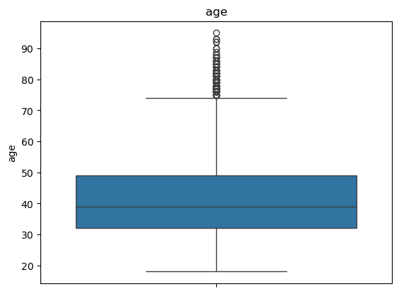

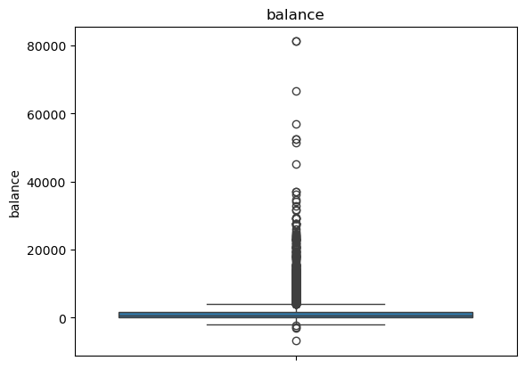

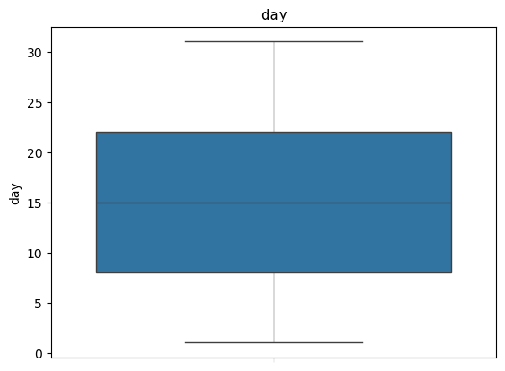

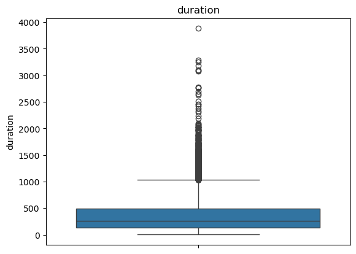

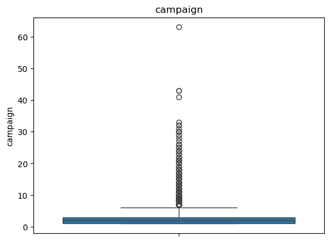

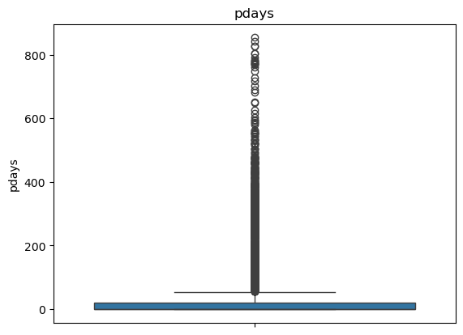

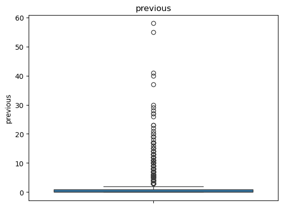

```python
for i in num_cols:
    plt.title(i)
    sns.boxplot(df[i])
    plt.show()
```

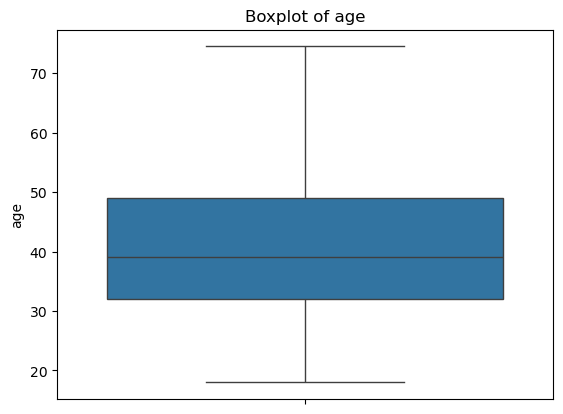

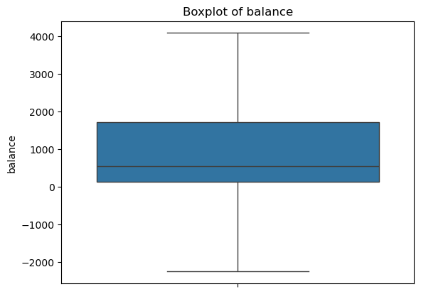

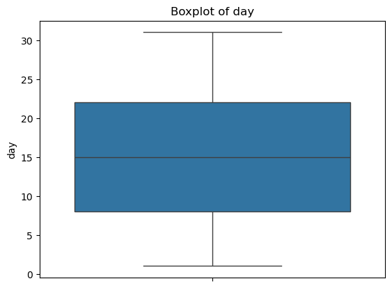

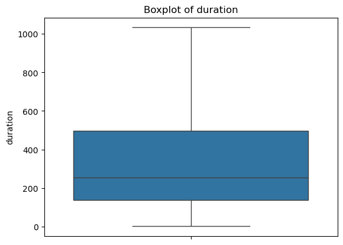

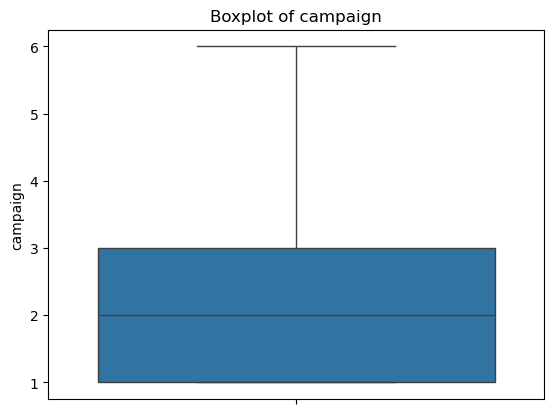

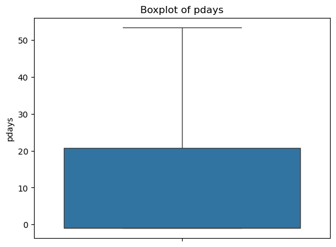

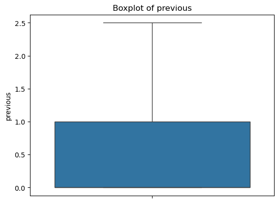

```python
for col in num_cols:
    Q1 = df[col].quantile(0.25)
    Q3 = df[col].quantile(0.75)
    IQR = Q3 - Q1
    lower = Q1 - 1.5 * IQR
    upper = Q3 + 1.5 * IQR
    df[col] = np.clip(df[col], lower, upper)
    sns.boxplot(y=df[col])
    plt.title(f'Boxplot of {col}')
    plt.show()
```

### There are no outliers in the categorical columns¶

```python
df.groupby('job')['balance'].mean()
```

```
job
admin.            954.515742
blue-collar       940.028807
entrepreneur     1042.231707
housemaid        1076.072993
management       1263.736555
retired          1589.105398
self-employed    1217.898765
services          893.334778
student          1152.536111
technician       1119.298409
unemployed       1085.899160
unknown          1350.385714
Name: balance, dtype: float64
```

• Retired customers have the highest average balance: 1589.11 • services(Hospitality ,Retail , Personal care workers...) have the lowest average balance: 893.33

# EDA :

## Univariate Analysis :

## Distribution of Jobs Among Clients

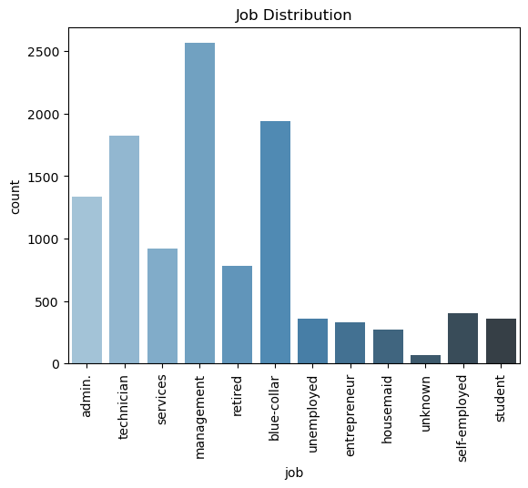

```python
sns.countplot(data=df, x='job',palette="Blues_d")
plt.title('Job Distribution')
plt.xticks(rotation=90)
plt.show()
```

## Distribution of Account Balances by Frequency

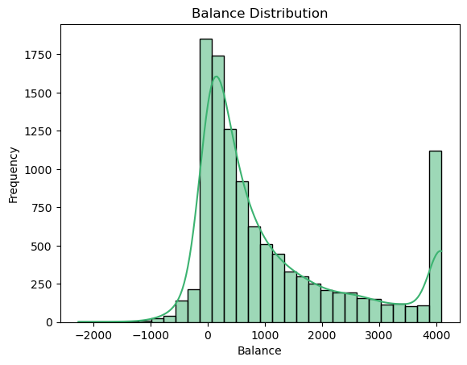

```python
sns.histplot(df['balance'], kde=True, bins=30, color='mediumseagreen')
plt.title('Balance Distribution')
plt.xlabel('Balance')
plt.ylabel('Frequency')
plt.show()
```

### The most frequent account balance in the dataset is 0, indicating that a significant number of clients either maintain no balance or have cleared their accounts. This may suggest limited savings behavior or a prevalence of low-income customers

## Preferred Contact methods of Clients

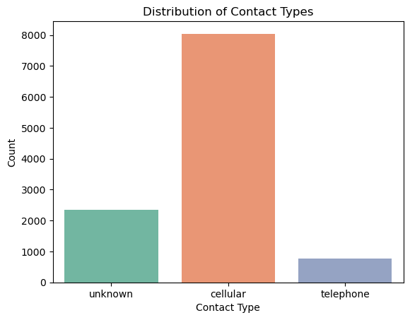

```python
palette="Set2"
sns.countplot(data=df, x='contact',palette=palette)
plt.title('Distribution of Contact Types')
plt.xlabel('Contact Type')
plt.ylabel('Count')
plt.show()
```

### The most common contact type used is cellular, which means most clients were contacted through their mobile phones.

## Client Education Level Distribution

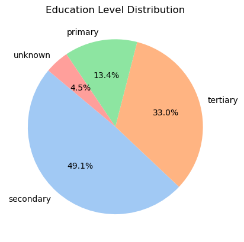

```python
df['education'].value_counts().plot.pie(autopct='%1.1f%%', startangle=140, colors=sns.color_palette('pastel'))
plt.title('Education Level Distribution')
plt.ylabel('')  # Optional: hides the y-axis label
plt.show()
```

### The largest proportion of clients, 49.1%, have a secondary level of education, suggesting that nearly half of the bank's customer base has completed high school or equivalent. This may reflect a middle-education demographic that could influence communication style and product offerings.

## Call Frequency by Duration

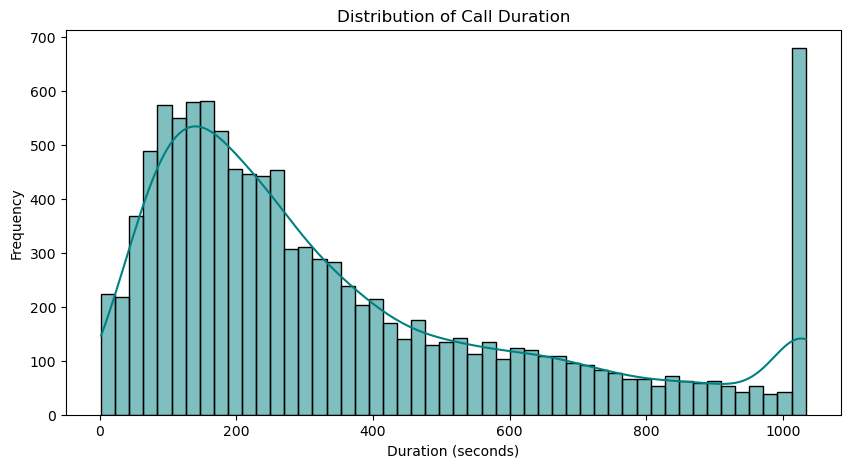

```python
plt.figure(figsize=(10,5))
sns.histplot(df['duration'], bins=50, kde=True, color='teal')
plt.title('Distribution of Call Duration')
plt.xlabel('Duration (seconds)')
plt.ylabel('Frequency')
plt.show()
```

## Client Age Distribution :

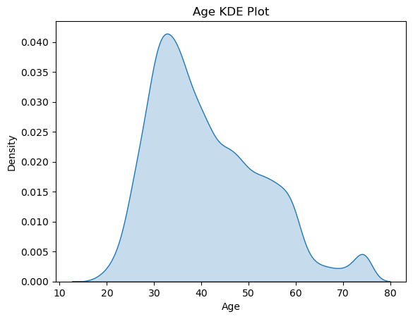

```python
sns.kdeplot(df['age'], shade=True)
plt.title('Age KDE Plot')
plt.xlabel('Age')
plt.show()
```

### The KDE plot reveals that the highest concentration of clients falls within the 30 to 40 age range, indicating that the bank’s customer base is primarily composed of middle-aged adults. This age group is often financially active, making them a key target for banking products and services.

# Bi variate Analysis :

## Relationship Between Age and Account Balance

```python
data=df.sample(50)
```

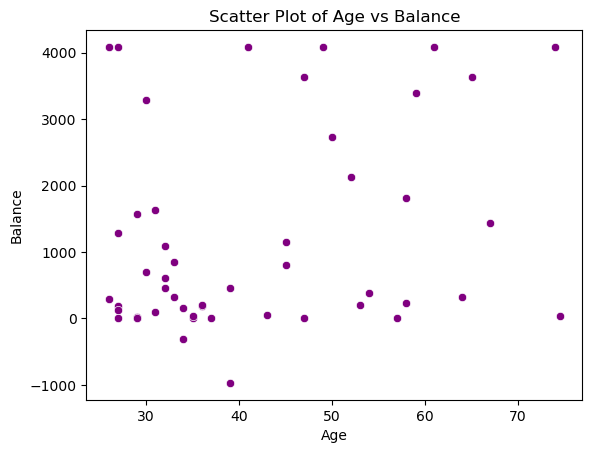

```python
sns.scatterplot(data=data, x='age', y='balance', color='purple')
plt.title('Scatter Plot of Age vs Balance')
plt.xlabel('Age')
plt.ylabel('Balance')
plt.show()
```

## Deposit Distribution by Marital Status

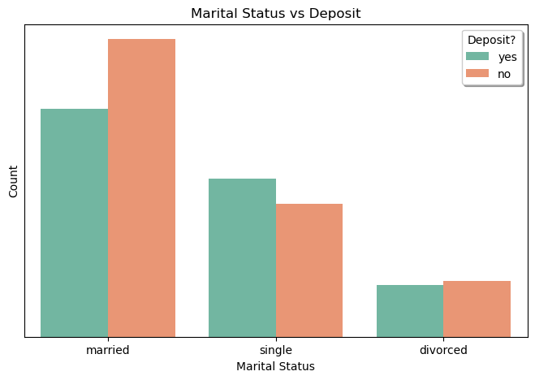

```python
palette = "Set2"

plt.figure(figsize=(8, 5))
sns.countplot(x='marital', hue='deposit', data=df, palette=palette)
plt.title('Marital Status vs Deposit')
plt.xlabel('Marital Status')
plt.ylabel('Count')
plt.yticks([])
plt.legend(title='Deposit?', ncol=1, fancybox=True, shadow=True)
plt.show()
```

### Most of the clients are married. But among them, more people did not deposit than those who did.

## Job Distribution by Deposit Status

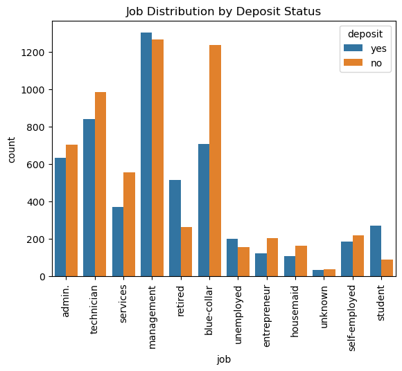

```python
sns.countplot(data=df, x='job', hue='deposit')
plt.title('Job Distribution by Deposit Status')
plt.xticks(rotation=90)
plt.show()
```

### The count plot shows that individuals in management roles are more likely to have made a deposit ('yes') compared to those who haven't deposited ('no'). This indicates that clients in management positions are more inclined to engage with the bank's deposit products, potentially due to greater financial stability or a higher level of trust in the bank's offerings.

## Average Account Balance Across Job Categories

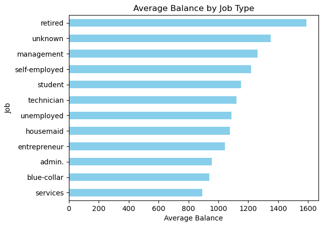

```python
job_balance = df.groupby('job')['balance'].mean().sort_values()
job_balance.plot(kind='barh', color='skyblue')
plt.title('Average Balance by Job Type')
plt.xlabel('Average Balance')
plt.ylabel('Job')
plt.show()
```

### The barh plot highlights that retired individuals have the highest average balance, at 1,600, compared to other job categories. This indicates that retirees tend to have more accumulated savings, which may suggest a focus on long-term financial security. As such, targeting retirees with specialized savings or investment products could be a strategic approach for the bank.

## Monthly Client Distribution by Deposit Status

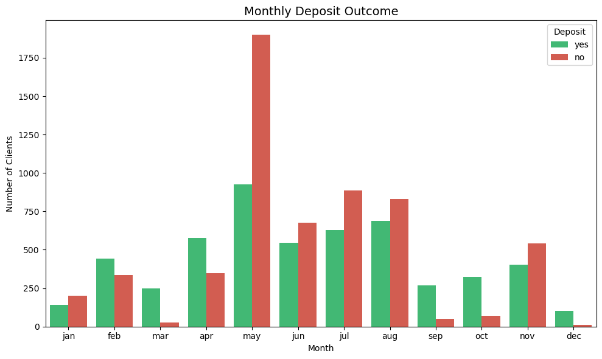

```python
# Define custom color palette for 'yes' and 'no'
custom_palette = {'yes': '#2ecc71', 'no': '#e74c3c'}  # green and red

# Order months properly
month_order = ['jan', 'feb', 'mar', 'apr', 'may', 'jun',
               'jul', 'aug', 'sep', 'oct', 'nov', 'dec']

# Plot
plt.figure(figsize=(10,6))
sns.countplot(data=df, x='month', hue='deposit', order=month_order, palette=custom_palette)
plt.title('Monthly Deposit Outcome', fontsize=14)
plt.xlabel('Month')
plt.ylabel('Number of Clients')
plt.legend(title='Deposit', loc='upper right')
plt.tight_layout()
plt.show()
```

### The count plot shows that May has the highest number of clients, but the majority have not made a deposit ('no') during this month.

## Impact of Housing Loan Status on Deposit Behavior

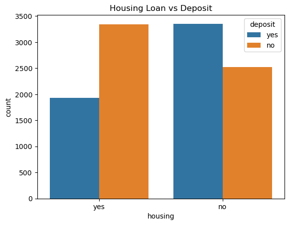

```python
sns.countplot(data=df, x='housing', hue='deposit')
plt.title('Housing Loan vs Deposit')
plt.show()
```

### The count plot indicates that in the 'Deposited' category, the majority of clients with housing loans have not made a deposit, suggesting that clients with housing loans might face financial constraints or prefer not to engage in deposit products. In contrast, in the 'NotDeposited' category, the majority of clients without a housing loan have made a deposit, which could imply that clients without such financial obligations are more likely to save. This suggests that the bank might benefit from understanding the financial dynamics of clients with housing loans to better promote deposit products.

# Multivariate Analysis :

## Client Feature Relationships colored by Deposit outcome

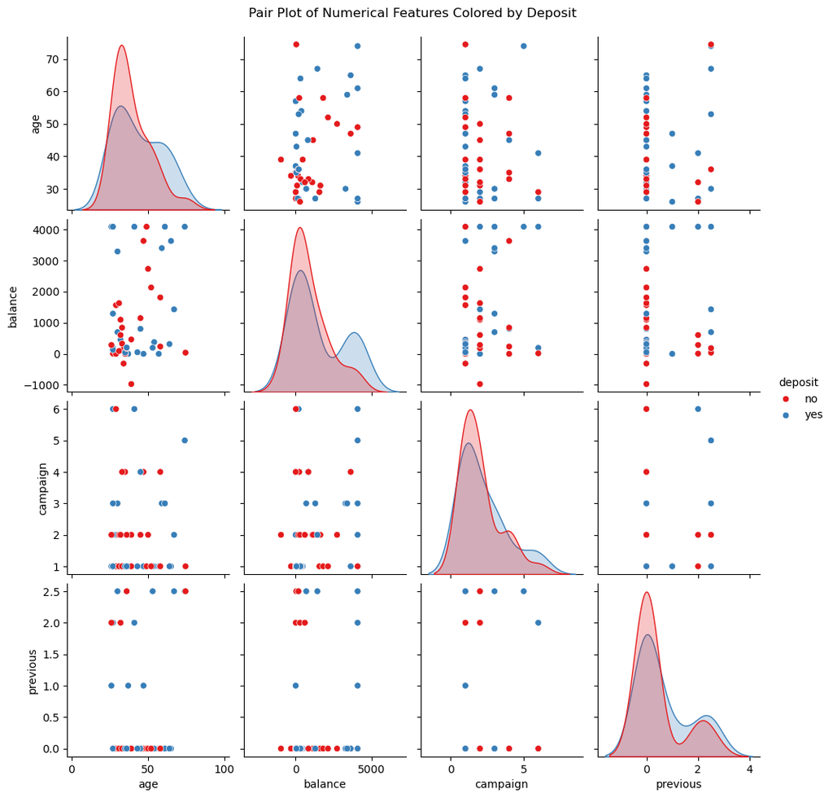

```python
sns.pairplot(data, vars=['age', 'balance', 'campaign', 'previous'], hue='deposit', palette='Set1')
plt.suptitle('Pair Plot of Numerical Features Colored by Deposit', y=1.02)
plt.show()
```

- The Pair plot suggest that balance, campaign, and previous are valuable features for predicting deposit outcomes.

## Client Features Correlation Heatmap

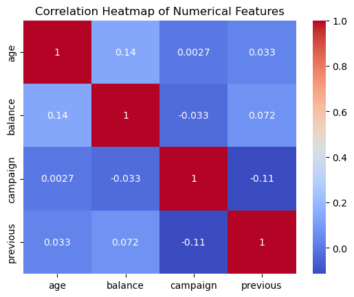

```python
corr = df[['age', 'balance', 'campaign', 'previous']].corr()
sns.heatmap(corr, annot=True, cmap='coolwarm')
plt.title('Correlation Heatmap of Numerical Features')
plt.show()
```

- The highest positive correlation is between age and balance (0.14), though still weak.
- campaign has a weak negative correlation with previous (-0.11), implying a slight inverse relationship.

# Feature Engineering

```python
# Create interaction term
df['campaign_previous'] = df['campaign'] * df['previous']
```

```python
df['campaign_previous']
```

```
0        0.0
1        0.0
2        0.0
3        0.0
4        0.0
        ...
11157    0.0
11158    0.0
11159    0.0
11160    5.0
11161    0.0
Name: campaign_previous, Length: 11162, dtype: float64
```

• campaign = number of contacts performed during this campaign • previous = number of contacts performed before this campaign By multiplying them: • Capturing the combined effect of how often a person has been contacted in total (both current and past campaigns).

```python
# Age Grouping :
```

```python
def age_group(age):
    if age < 30:
        return 'Young'
    elif age < 60:
        return 'Middle-aged'
    else:
        return 'Senior'
df['age_group'] = df['age'].apply(age_group)
```

```python
df['age_group']
```

```
0        Middle-aged
1        Middle-aged
2        Middle-aged
3        Middle-aged
4        Middle-aged
            ...
11157    Middle-aged
11158    Middle-aged
11159    Middle-aged
11160    Middle-aged
11161    Middle-aged
Name: age_group, Length: 11162, dtype: object
```

```python
# Balance Level Binning :
```

```python
def balance_level(balance):
    if balance < 0:
        return 'Debt'
    elif balance < 1000:
        return 'Low'
    elif balance < 5000:
        return 'Medium'
    else:
        return 'High'
df['balance_level'] = df['balance'].apply(balance_level)
```

```python
df['balance_level']
```

```
0        Medium
1           Low
2        Medium
3        Medium
4           Low
          ...
11157       Low
11158       Low
11159       Low
11160       Low
11161       Low
Name: balance_level, Length: 11162, dtype: object
```

```python
# Checking the customer has any loans
```

```python
def check_any_loan(row):
    if row['housing'] == 'yes' or row['loan'] == 'yes':
        return 1
    else:
        return 0

df['has_any_loan'] = df.apply(check_any_loan, axis=1)
```

```python
df['has_any_loan']
```

```
0        1
1        0
2        1
3        1
4        0
        ..
11157    1
11158    0
11159    0
11160    1
11161    0
Name: has_any_loan, Length: 11162, dtype: int64
```

# Label Encoding :

```python
# Encode categorical variables
from sklearn.preprocessing import LabelEncoder

le = LabelEncoder()

for col in df.select_dtypes(include='object').columns:
    df[col] = le.fit_transform(df[col])

df
```

|  | age | job | marital | education | balance | housing | loan | contact | day | month | duration | campaign | pdays | previous | poutcome | deposit | campaign_previous | age_group | balance_level | has_any_loan |
| --- | --- | --- | --- | --- | --- | --- | --- | --- | --- | --- | --- | --- | --- | --- | --- | --- | --- | --- | --- | --- |
| 0 | 59.0 | 0 | 1 | 1 | 2343 | 1 | 0 | 2 | 5 | 8 | 1033 | 1 | -1.000 | 0.0 | 3 | 1 | 0.0 | 0 | 2 | 1 |
| 1 | 56.0 | 0 | 1 | 1 | 45 | 0 | 0 | 2 | 5 | 8 | 1033 | 1 | -1.000 | 0.0 | 3 | 1 | 0.0 | 0 | 1 | 0 |
| 2 | 41.0 | 9 | 1 | 1 | 1270 | 1 | 0 | 2 | 5 | 8 | 1033 | 1 | -1.000 | 0.0 | 3 | 1 | 0.0 | 0 | 2 | 1 |
| 3 | 55.0 | 7 | 1 | 1 | 2476 | 1 | 0 | 2 | 5 | 8 | 579 | 1 | -1.000 | 0.0 | 3 | 1 | 0.0 | 0 | 2 | 1 |
| 4 | 54.0 | 0 | 1 | 2 | 184 | 0 | 0 | 2 | 5 | 8 | 673 | 2 | -1.000 | 0.0 | 3 | 1 | 0.0 | 0 | 1 | 0 |
| ... | ... | ... | ... | ... | ... | ... | ... | ... | ... | ... | ... | ... | ... | ... | ... | ... | ... | ... | ... | ... |
| 11157 | 33.0 | 1 | 2 | 0 | 1 | 1 | 0 | 0 | 20 | 0 | 257 | 1 | -1.000 | 0.0 | 3 | 0 | 0.0 | 0 | 1 | 1 |
| 11158 | 39.0 | 7 | 1 | 1 | 733 | 0 | 0 | 2 | 16 | 6 | 83 | 4 | -1.000 | 0.0 | 3 | 0 | 0.0 | 0 | 1 | 0 |
| 11159 | 32.0 | 9 | 2 | 1 | 29 | 0 | 0 | 0 | 19 | 1 | 156 | 2 | -1.000 | 0.0 | 3 | 0 | 0.0 | 0 | 1 | 0 |
| 11160 | 43.0 | 9 | 1 | 1 | 0 | 0 | 1 | 0 | 8 | 8 | 9 | 2 | 53.375 | 2.5 | 0 | 0 | 5.0 | 0 | 1 | 1 |
| 11161 | 34.0 | 9 | 1 | 1 | 0 | 0 | 0 | 0 | 9 | 5 | 628 | 1 | -1.000 | 0.0 | 3 | 0 | 0.0 | 0 | 1 | 0 |

11162 rows × 20 columns

# Robust Scaling :

```python
# To save column names
columns=df.columns
```

```python
from sklearn.preprocessing import RobustScaler
scaler = RobustScaler()
scaled_array = scaler.fit_transform(df)
# Convert back to DataFrame
df=pd.DataFrame(scaled_array,columns=columns)
scaled_array
```

```
array([[ 1.17647059, -0.66666667,  0.        , ...,  0.        ,
         1.        ,  0.        ],
       [ 1.        , -0.66666667,  0.        , ...,  0.        ,
         0.        , -1.        ],
       [ 0.11764706,  0.83333333,  0.        , ...,  0.        ,
         1.        ,  0.        ],
       ...,
       [-0.41176471,  0.83333333,  1.        , ...,  0.        ,
         0.        , -1.        ],
       [ 0.23529412,  0.83333333,  0.        , ...,  0.        ,
         0.        ,  0.        ],
       [-0.29411765,  0.83333333,  0.        , ...,  0.        ,
         0.        , -1.        ]])
```

# Train Test Split :

• Training set — to train the model

• Test set — to check how well the model performs on new/unseen data

### Defining Features and Target:

```python
x = df.drop("deposit", axis=1)
y = df["deposit"]
```

```python
x_train, x_test, y_train, y_test = train_test_split(x, y, test_size=0.2, stratify=y, random_state=42)
```

### Logistic model :

```python
from sklearn.linear_model import LogisticRegression
log_reg=LogisticRegression()
log_reg.fit(x_train, y_train) # scaled one
log_pred = log_reg.predict(x_test)
accuracy = accuracy_score(y_test, log_pred)
print("Accuracy :",accuracy*100)
```

```
Accuracy : 80.20600089565608
```

### XGB Model :

```python
from xgboost import XGBClassifier
xg=XGBClassifier()
xg.fit(x_train,y_train)
xgb_pred=xg.predict(x_test)
accuracy = accuracy_score(y_test, xgb_pred)
print("Accuracy :",accuracy*100)
```

```
Accuracy : 84.99776085982982
```

### Random Forest Model :

```python
from sklearn.ensemble import RandomForestClassifier
ran=RandomForestClassifier()
ran.fit(x_train,y_train)
rf_pred=ran.predict(x_test)
accuracy = accuracy_score(y_test, rf_pred)
print("Accuracy :",accuracy*100)
```

```
Accuracy : 84.10210479175997
```

### KNN Model :

```python
from sklearn.neighbors import KNeighborsClassifier
kn=KNeighborsClassifier()
kn.fit(x_train,y_train)
knn_pred=kn.predict(x_test)
accuracy = accuracy_score(y_test, knn_pred)
print("Accuracy :",accuracy*100)
```

```
Accuracy : 80.11643528884909
```

### LightGBM Model :

```python
from lightgbm import LGBMClassifier
lgbm=LGBMClassifier(verbose=-1)
lgbm.fit(x_train,y_train)
lgbm_pred=lgbm.predict(x_test)
accuracy = accuracy_score(y_test, lgbm_pred)
print("Accuracy :",accuracy*100)
```

```
Accuracy : 85.84863412449619
```

### CatBoost Model :

```python
from catboost import CatBoostClassifier
cat=CatBoostClassifier(
    verbose=0,
    random_seed=42,
    eval_metric='Accuracy',
    early_stopping_rounds=50
)
cat.fit(x_train,y_train)
cat_pred=cat.predict(x_test)
accuracy = accuracy_score(y_test, cat_pred)
print("Accuracy :",accuracy*100)
```

```
Accuracy : 86.69950738916256
```

# Hyper Parameter Tuning :

```python
param_dist = {
    'depth': [6, 8, 10],
    'learning_rate': [0.01, 0.03, 0.05],
    'iterations': [300, 500, 700],
    'l2_leaf_reg': [3, 5, 7, 9],
    'bootstrap_type': ['Bayesian', 'Bernoulli'],
    'subsample': [0.7, 0.8, 0.9]
}

random_search_cat = RandomizedSearchCV(
    estimator=cat,
    param_distributions=param_dist,
    n_iter=25,
    scoring='accuracy',
    cv=5,
    verbose=1,
    n_jobs=-1,
    random_state=42
)

random_search_cat.fit(x_train, y_train)

# Best model evaluation
best_cat = random_search_cat.best_estimator_
y_pred_best = best_cat.predict(x_test)
print("Tuned Accuracy:", accuracy_score(y_test, y_pred_best))
print("Best Parameters:", random_search_cat.best_params_)
```

```
Fitting 5 folds for each of 25 candidates, totalling 125 fits
Tuned Accuracy: 0.8629646215853113
Best Parameters: {'subsample': 0.7, 'learning_rate': 0.05, 'l2_leaf_reg': 9, 'iterations': 700, 'depth': 6, 'bootstrap_type': 'Bernoulli'}
```

# Model Accuracy Comparison Table

```python
from tabulate import tabulate
from sklearn.metrics import accuracy_score

table = [
    ['Model', 'Accuracy'],
    ['Logistic Regression', f"{accuracy_score(y_test, log_pred)*100:.2f}%"],
    ['XGB Classifier', f"{accuracy_score(y_test, xgb_pred)*100:.2f}%"],
    ['Random Forest', f"{accuracy_score(y_test, rf_pred)*100:.2f}%"],
    ['KNN', f"{accuracy_score(y_test, knn_pred)*100:.2f}%"],
    ['LightGBM', f"{accuracy_score(y_test, lgbm_pred)*100:.2f}%"],
    ['CatBoost', f"{accuracy_score(y_test, cat_pred)*100:.2f}%"]
]

print(tabulate(table, headers='firstrow', tablefmt='fancy_grid'))
```

```
╒═════════════════════╤════════════╕
│ Model               │ Accuracy   │
╞═════════════════════╪════════════╡
│ Logistic Regression │ 80.21%     │
├─────────────────────┼────────────┤
│ XGB Classifier      │ 85.00%     │
├─────────────────────┼────────────┤
│ Random Forest       │ 84.10%     │
├─────────────────────┼────────────┤
│ KNN                 │ 80.12%     │
├─────────────────────┼────────────┤
│ LightGBM            │ 85.85%     │
├─────────────────────┼────────────┤
│ CatBoost            │ 86.70%     │
╘═════════════════════╧════════════╛
```

# Comparison of Model Accuracies

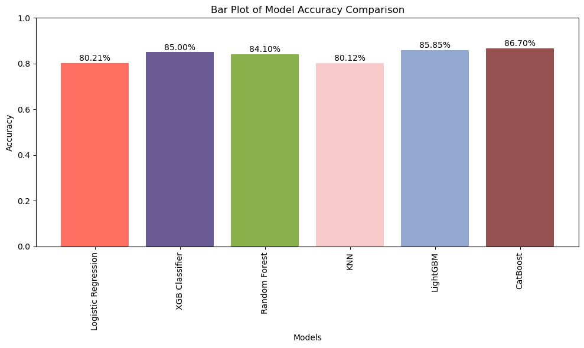

```python
from sklearn.metrics import accuracy_score
import matplotlib.pyplot as plt

models = ['Logistic Regression', 'XGB Classifier', 'Random Forest', 'KNN', 'LightGBM', 'CatBoost']
accuracies = [
    accuracy_score(y_test, log_pred),
    accuracy_score(y_test, xgb_pred),
    accuracy_score(y_test, rf_pred),
    accuracy_score(y_test, knn_pred),
    accuracy_score(y_test, lgbm_pred),
    accuracy_score(y_test, cat_pred)
]
# Custom colors for each bar
colors = ['#FF6F61', '#6B5B95', '#88B04B', '#F7CAC9', '#92A8D1', '#955251']

plt.figure(figsize=(10, 6))
bars = plt.bar(models, accuracies, color=colors)
plt.ylim(0, 1)
plt.title('Bar Plot of Model Accuracy Comparison')
plt.xlabel('Models')
plt.ylabel('Accuracy')
plt.xticks(rotation=90)

for bar, acc in zip(bars, accuracies):
    plt.text(bar.get_x() + bar.get_width()/2, acc + 0.01, f'{acc:.2%}', ha='center')

plt.tight_layout()
plt.show()
```

## Predict and Evaluate :

```python
y_pred = cat.predict(x_test)
print("CatBoost Accuracy:", accuracy_score(y_test, y_pred))
print("\nClassification Report:\n", classification_report(y_test, y_pred))
print("Confusion Matrix:\n", confusion_matrix(y_test, y_pred))
```

```
CatBoost Accuracy: 0.8669950738916257

Classification Report:
               precision    recall  f1-score   support

         0.0       0.90      0.84      0.87      1175
         1.0       0.84      0.89      0.86      1058

    accuracy                           0.87      2233
   macro avg       0.87      0.87      0.87      2233
weighted avg       0.87      0.87      0.87      2233

Confusion Matrix:
 [[992 183]
 [114 944]]
```

[output not shown]

Predicted | NotDeposited | Deposited --------------------------------------- Actual: NotDeposited | 992 | 183 Deposited | 114 | 944True Negatives (TN) = 992 – Correctly predicted NotDeposited False Positives (FP) = 183 – Predicted Deposited, but actually NotDeposited False Negatives (FN) = 114 – Predicted NotDeposited, but actually Deposited True Positives (TP) = 944 – Correctly predicted Deposited

## Feature Importance Visualization :

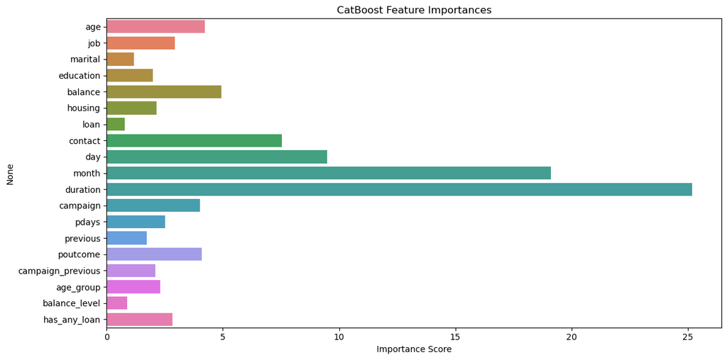

```python
plt.figure(figsize=(12, 6))
importances = cat.get_feature_importance()
feature_names = x.columns
colors=sns.color_palette("husl",len(feature_names))
sns.barplot(x=importances, y=feature_names,palette=colors)
plt.title("CatBoost Feature Importances")
plt.xlabel("Importance Score")
plt.tight_layout()
plt.show()
```